# EAS 648 Lab1

Zirui Peng

2022-10-28

# Lab Setup

```r
#Set working directory
setwd("F:/GOBLUE/22FALL/EAS648/lab1")

#Load packages
library(rio)
library(tidyverse)
library(sf)
library(janitor)
library(tmap)

# if(!require(pacman))install.packages("pacman")
# Install the latest version of the Epi R Handbook package to download related data
# pacman::p_install_gh("appliedepi/epirhandbook")
# pacman::p_load(epirhandbook)
# download_book()
```

# Ebola Epidemic Data

```r
# Download simulated Ebola epidemic dataframe (Only the first time knit needs to be run get_data)
# get_data(file = "linelist_cleaned.rds")
linelist = import("linelist_cleaned.rds")

# Convert class dataframe to spatial feature 'sf';
# Columns 'lon' and 'lat' have been designated as coordinate columns;
# 4326 identifies our coordinates as based on the World Geodetic System 1984 (WGS84)
linelist_sf <- linelist %>%
     sf::st_as_sf(coords = c("lon", "lat"), crs = 4326)
head(linelist_sf)
```

```
## Simple feature collection with 6 features and 28 fields
## Geometry type: POINT
## Dimension:     XY
## Bounding box:  xmin: -13.23637 ymin: 8.451719 xmax: -13.21291 ymax: 8.475476
## Geodetic CRS:  WGS 84
##   case_id generation date_infection date_onset date_hospitalisation
## 1  5fe599          4     2014-05-08 2014-05-13           2014-05-15
## 2  8689b7          4           <NA> 2014-05-13           2014-05-14
## 3  11f8ea          2           <NA> 2014-05-16           2014-05-18
## 4  b8812a          3     2014-05-04 2014-05-18           2014-05-20
## 5  893f25          3     2014-05-18 2014-05-21           2014-05-22
## 6  be99c8          3     2014-05-03 2014-05-22           2014-05-23
##   date_outcome outcome gender age age_unit age_years age_cat age_cat5
## 1         <NA>    <NA>      m   2    years         2     0-4      0-4
## 2   2014-05-18 Recover      f   3    years         3     0-4      0-4
```

[output cut: 25 more lines]

# Admin Boundary Shapefiles

```r
# Download Sierra Leone Admin boundary shapefiles (Only the first time knit needs to be run get_data)
# get_data(file = "sle_adm3.shp")
sle_adm3_raw = st_read("sle_adm3.shp") # Import the shapefile
sle_adm3 <- sle_adm3_raw %>%
  clean_names() %>% # Clean the column names
  filter(admin2name %in% c("Western Area Urban", "Western Area Rural")) # Filter rows to keep only areas of interest
head(sle_adm3)
```

```
## Simple feature collection with 6 features and 19 fields
## Geometry type: MULTIPOLYGON
## Dimension:     XY
## Bounding box:  xmin: -13.29416 ymin: 8.094272 xmax: -12.91333 ymax: 8.494073
## Geodetic CRS:  WGS 84
##   objectid     admin3name admin3pcod    admin3ref_n         admin2name
## 1      155     Koya Rural   SL040101     Koya Rural Western Area Rural
## 2      156 Mountain Rural   SL040102 Mountain Rural Western Area Rural
## 3      157 Waterloo Rural   SL040103 Waterloo Rural Western Area Rural
## 4      158     York Rural   SL040104     York Rural Western Area Rural
## 5      159      Central I   SL040201      Central I Western Area Urban
## 6      160         East I   SL040203         East I Western Area Urban
##   admin2pcod admin1name admin1pcod   admin0name admin0pcod       date
## 1     SL0401    Western       SL04 Sierra Leone         SL 2016-08-01
## 2     SL0401    Western       SL04 Sierra Leone         SL 2016-08-01
```

[output cut: 18 more lines]

# Health Facilities

```r
# Download Sierra Leone Health facility data from OpenStreetMap (Only the first time knit needs to be run get_data)
# get_data(file = "sle_hf.shp")
sle_hf <- sf::read_sf("sle_hf.shp") %>%
  clean_names() %>%
  filter(amenity %in% c("hospital", "clinic", "doctors")) #filter to keep only the points tagged as either “hospital”, “clinic”, or “doctors”.
head(sle_hf)
```

```
## Simple feature collection with 6 features and 11 fields
## Geometry type: POINT
## Dimension:     XY
## Bounding box:  xmin: -13.264 ymin: 8.38842 xmax: -13.14276 ymax: 8.490478
## Geodetic CRS:  WGS 84
## # A tibble: 6 × 12
##      osm_id source addrf…¹ build…² healt…³ opera…⁴ addrc…⁵ name  amenity healt…⁶
##       <dbl> <chr>  <chr>   <chr>   <chr>   <chr>   <chr>   <chr> <chr>   <chr>
## 1    3.20e9 UNMEE… <NA>    <NA>    <NA>    <NA>    <NA>    Chin… hospit… <NA>
## 2    3.20e9 UNMEE… <NA>    <NA>    <NA>    <NA>    <NA>    Lakk… hospit… <NA>
## 3    3.21e9 https… <NA>    <NA>    <NA>    <NA>    <NA>    Prin… hospit… <NA>
## 4    3.34e9 MSF-CH <NA>    <NA>    <NA>    <NA>    <NA>    COMM… clinic  <NA>
## 5    3.34e9 MSF-CH <NA>    <NA>    <NA>    <NA>    <NA>    Den … clinic  <NA>
## 6    3.34e9 <NA>   <NA>    <NA>    <NA>    <NA>    <NA>    MABE… clinic  <NA>
## # … with 2 more variables: capacitype <chr>, geometry <POINT [°]>, and
## #   abbreviated variable names ¹addrfull, ²building, ³healthcare, ⁴operatorty,
## #   ⁵addrcity, ⁶healthca_1
```

# Plot Ebola Epidemic Point Distribution

```r
tmap_mode("plot") # set the tmap mode as static (“plot” mode)
```

```
## tmap mode set to plotting
```

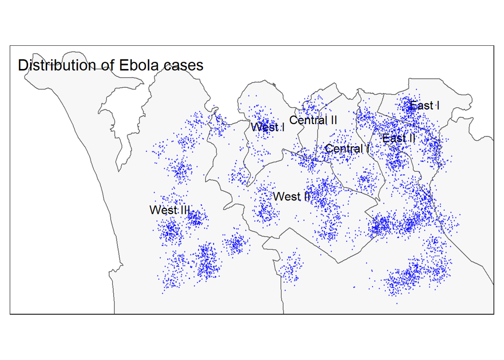

```r
tm_shape(sle_adm3, bbox = c(-13.3, 8.445, -13.2, 8.5)) +
  tm_polygons(col = "#F7F7F7") +
  tm_borders(col = "#000000", lwd = 2) +
  tm_text("admin3name")+
  tm_shape(linelist_sf) +
  tm_dots(size=0.01, col='blue', alpha = 0.5) +
  tm_layout(title = "Distribution of Ebola cases")
```

**Explain:**  
Simple overlay of Ebola Epidemic Cases on top of Admin Boundary Shapefiles as a static image. It is not difficult to observe that there are multiple outbreak centers of Ebola Epidemic Cases in every administrative region.

# Ebola Epidemic Cases by Administrative Unit

```r
linelist_adm <- linelist_sf %>% # join the administrative boundary file to the linelist, based on spatial intersection
  sf::st_join(sle_adm3, join = st_intersects) %>%
  select(names(linelist_sf), admin3name, admin3pcod) # Keep the linelist_sf column names and two new admin ones of interest

# Count cases by administrative unit
case_adm3 <- linelist_adm %>%
  as_tibble() %>%                      # convert to tibble for better display
  group_by(admin3pcod, admin3name) %>% # group by admin unit, both by name and pcode
  summarise(cases = n()) %>%           # summarize and count rows
  arrange(desc(cases))                 # arrange in descending order
head(case_adm3)
```

```
## # A tibble: 6 × 3
## # Groups:   admin3pcod [6]
##   admin3pcod admin3name     cases
##   <chr>      <chr>          <int>
## 1 SL040102   Mountain Rural  1667
## 2 SL040208   West III        1332
## 3 SL040207   West II         1061
## 4 SL040204   East II          657
## 5 SL040201   Central I        344
## 6 SL040203   East I           323
```

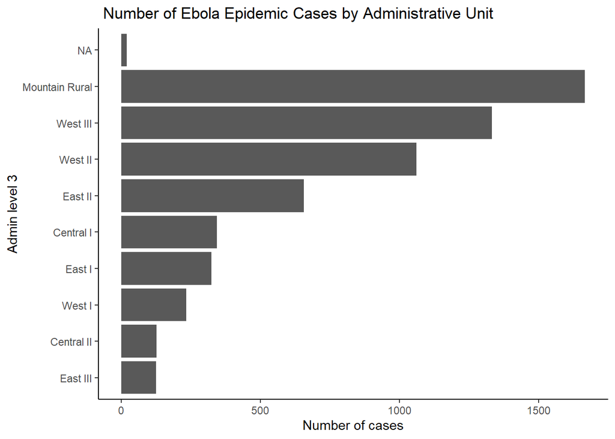

```r
# Create a bar plot of case counts by administrative unit
ggplot( data = linelist_adm, mapping = aes(x = fct_rev(fct_infreq(admin3name))))+ # x-axis is admin units, ordered by reversed frequency
  geom_bar()+ # create bars, height is number of rows
  coord_flip()+ # flip X and Y axes
  theme_classic()+ # simplify background
  labs( x = "Admin level 3", y = "Number of cases", title = " Number of Ebola Epidemic Cases by Administrative Unit") # titles and labels
```

**Explain:**  
The Ebola Epidemic cases data does not contain any information about the administrative units. So I use the st_intersects function to join the administrative boundary file to the Ebola Epidemic cases data.  
In this way, the number of Ebola Epidemic cases in the corresponding area can be counted according to the administrative unit, and then sorted by descending order, which area is most likely to be infected at a glance. In this data, the Mountain Rural region has the most Ebola Epidemic cases.

# Finding the Nearest Health Facility or Catchment Area

```r
linelist_sf_hf <- linelist_sf %>%
  st_join(sle_hf, join = st_nearest_feature) %>%   # data from nearest clinic joined to case data
  select(case_id, osm_id, name, amenity) %>%       # keep columns of interest, including id, name, type, and geometry of healthcare facility
  rename("nearest_clinic" = "name")                # re-name for clarity
head(linelist_sf_hf)
```

```
## Simple feature collection with 6 features and 4 fields
## Geometry type: POINT
## Dimension:     XY
## Bounding box:  xmin: -13.23637 ymin: 8.451719 xmax: -13.21291 ymax: 8.475476
## Geodetic CRS:  WGS 84
##   case_id     osm_id                  nearest_clinic  amenity
## 1  5fe599 6979628967 Shriners Hospitals for Children hospital
## 2  8689b7 6979628967 Shriners Hospitals for Children hospital
## 3  11f8ea 6979628967 Shriners Hospitals for Children hospital
## 4  b8812a 3341831443                      Den Clinic   clinic
## 5  893f25 6979628967 Shriners Hospitals for Children hospital
## 6  be99c8 6979628967 Shriners Hospitals for Children hospital
##                     geometry
## 1 POINT (-13.21574 8.468973)
## 2 POINT (-13.21523 8.451719)
## 3 POINT (-13.21291 8.464817)
## 4 POINT (-13.23637 8.475476)
## 5 POINT (-13.22286 8.460824)
## 6 POINT (-13.22263 8.461831)
```

```r
hf_catchment <- linelist_sf_hf %>%
  as.data.frame() %>%                          # convert from shapefile to dataframe
  count(nearest_clinic, name = "case_n") %>%   # count rows by nearest_clinic,assign new counts column as "case_n"
  arrange(desc(case_n))                        # arrange in descending order
hf_catchment
```

```
##                          nearest_clinic case_n
## 1                            Den Clinic   2110
## 2       Shriners Hospitals for Children   1956
## 3         GINER HALL COMMUNITY HOSPITAL   1033
## 4                             panasonic    293
## 5 Princess Christian Maternity Hospital    196
## 6                     ARAB EGYPT CLINIC    129
## 7                                  <NA>     90
## 8                  MABELL HEALTH CENTER     81
```

```r
# Plot the cases and clinic points
tmap_mode("view")   # set the tmap mode as interactive
```

```
## tmap mode set to interactive viewing
```

```r
tm_shape(linelist_sf_hf) +
  tm_dots(size=0.01, col='nearest_clinic') +     # Ebola Epidemic cases colored by nearest clinic
  tm_shape(sle_hf) +
  tm_dots(size=0.1, col='black', alpha = 0.4) +  # plot clinic facilities in large black dots
  tm_text("name") +                              # overlay with name of facility
  tm_layout(title = "Ebola Epidemic Cases Colored by Nearest Clinic")
```

[interactive chart not shown]

**Explain:**  
Draw a dynamic map based on Leaflet, reflecting the clinic closest to each Ebola Epidemic Cases.  
In order to distinguish the infected cases and the locations of medical institutions, the clinic distribution is represented by a black circle with a larger diameter, while the Ebola Epidemic cases are represented by a smaller colored circle, and the corresponding colors are assigned according to the results of the nearest neighbor analysis.